# Logistic Regression

### Preparing environment

```r
library(tidyverse)
```

```r
library(dplyr)
library(ggplot2)
```

### Assignment task 2 - reading the csv file I wrangled

```r
alc <- read.csv("C:/Users/nicol/Downloads/PHD_302/IODS-project/data/Assignement3_Logistic_Regression/alc.csv")
```

### Assignment task 3 - creating hypotheses

#### I think that alcohol consumption with correlate in the following ways:

##### 1) famrel, if the family relationship is higher alc_use will be lower

##### 2) goout will correlate with alc_use, more time for going out more time for alcohol consumption

##### 3) failures will correlate with alc_use, one reason for poor academic performance could be higher alcohol consumption

##### 4) higher variable no will correlate with higher alcohol consumption

### Assignment task 4 - Exlporing the data

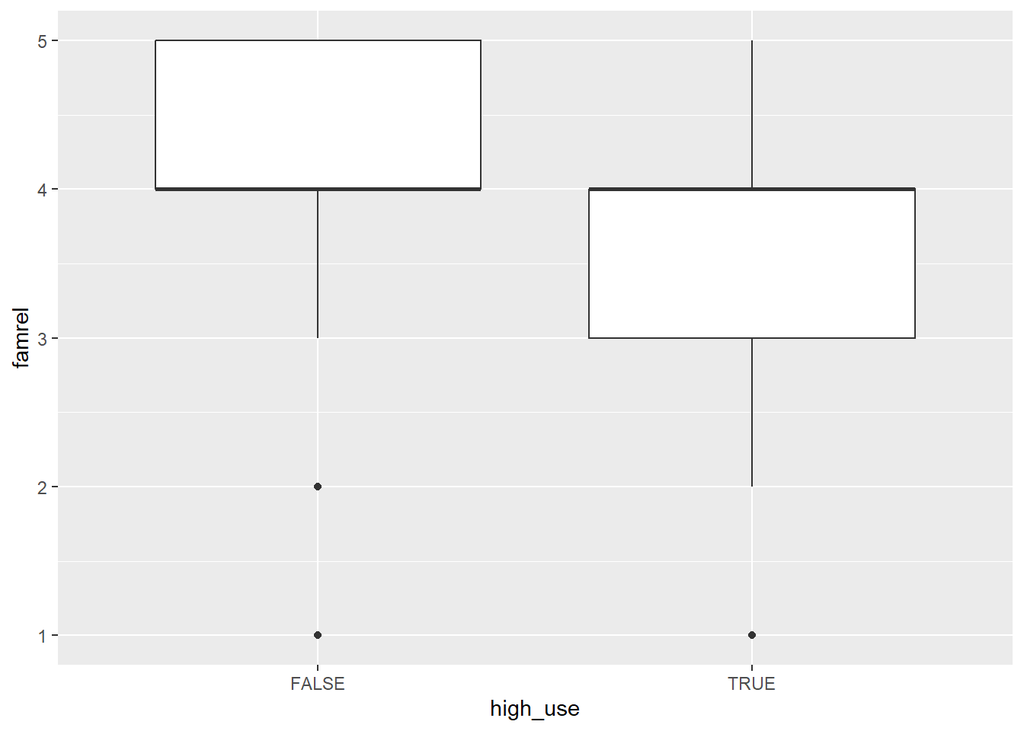

```r
g1 <- ggplot(data = alc, aes(x = high_use, y = famrel))
g1 + geom_boxplot() + ylab("famrel")
```

####Interesting, there seems to be a trend here that higher familial relationships do correlate with less alcohol consumption but it seems weak. My prediction is that if I use famrel as a variable in my logistic regression it will not give a strong Rsquared value.

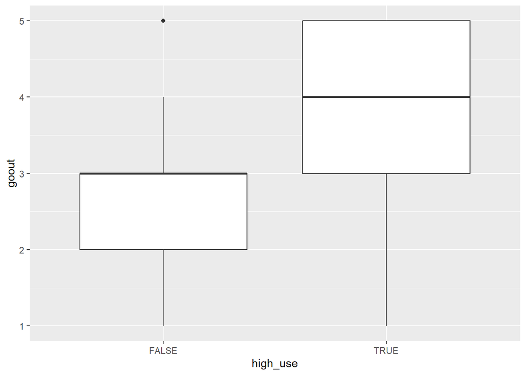

```r
g2 <- ggplot(data = alc, aes(x = high_use, y = goout))
g2 + geom_boxplot() + ylab("goout")
```

####Here I see my guess of people going out more also drinking more to be true. I feel this is slighlty stonger than famrel, by eye. I would think this would correlate with alcohol high use true.

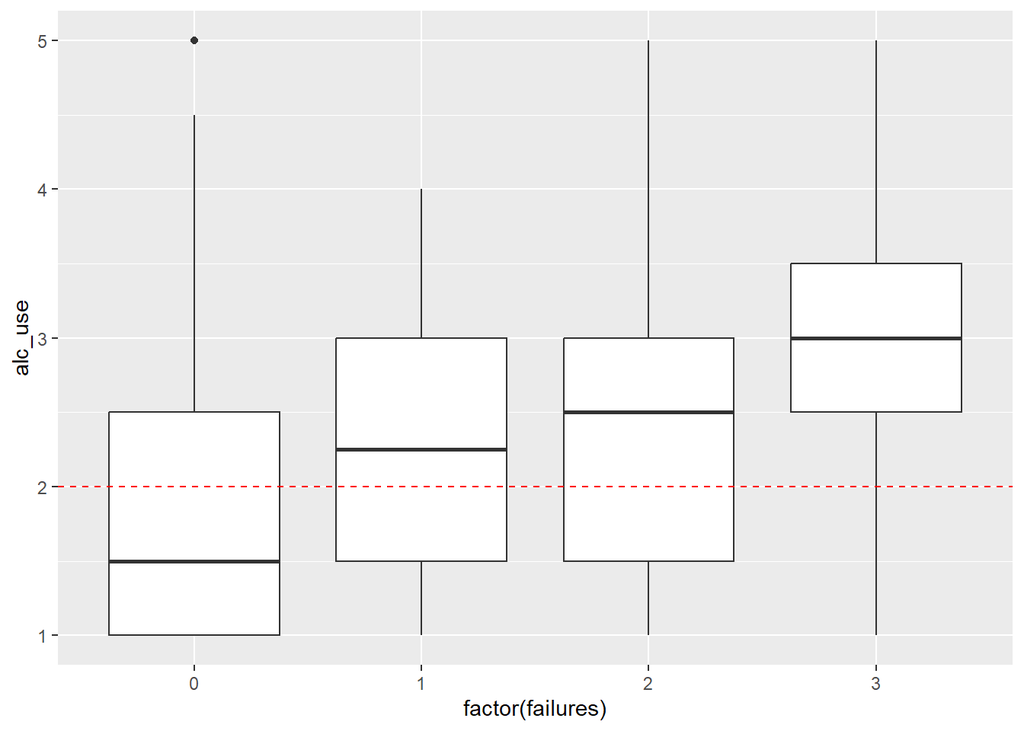

```r
ggplot(data=alc, aes(x=factor(failures),y=alc_use))+
  geom_boxplot()+
  geom_hline(yintercept = 2, linetype="dashed", colour="red")
```

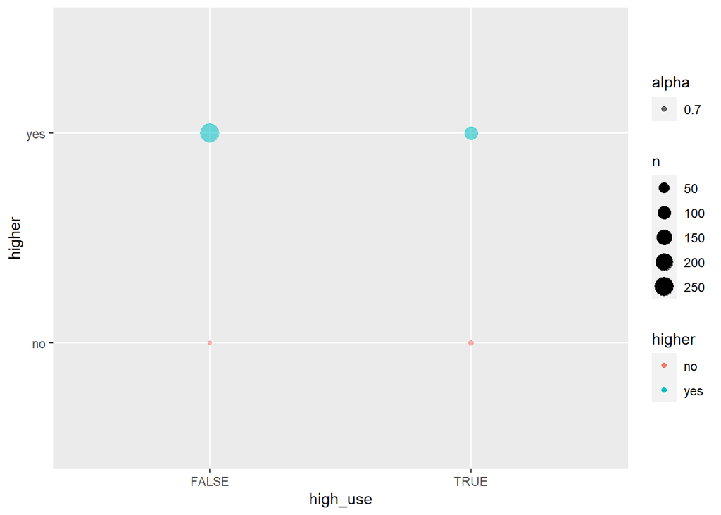

```r
g3 <- ggplot(data = alc, aes(x = high_use, y = higher))
g3 + geom_count(aes(high_use, higher, alpha = 0.7, colour = higher))
```

####Here I had a hard time finding a plot that would show me the comparison I wanted. It is one of my learning pains in dealing with data visualization, finding the right plot type. But here I can see that of the people who don’t have higher education aspirations there isn’t much of a difference in high_use. But of those who do (who also make up the majority of the students), there are more students who want to go to higher eduction who don’t fall into high_use than do, which corresponds to my guess but perhaps not strongily.

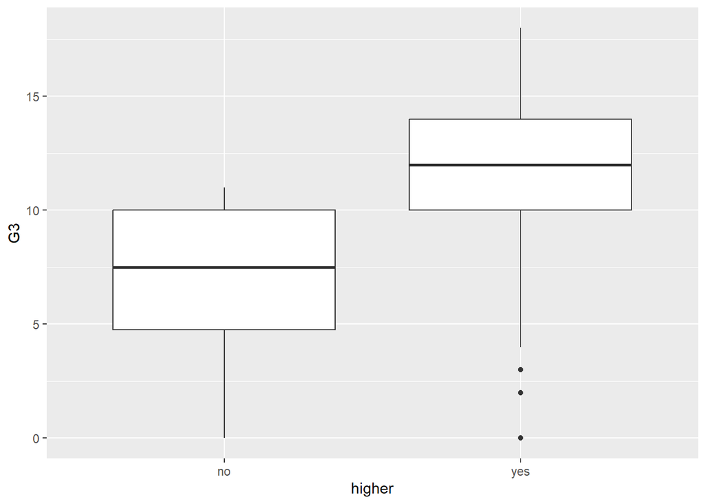

```r
g4 <- ggplot(data = alc, aes(x = higher, y = G3))
g4 + geom_boxplot() + ylab("G3")
```

####was interested to see if the ambition for higher education also correlated with grades, it seems to. Intresting

### Assignment task 5 - logistic regression

```r
m <- glm(high_use ~ famrel + failures + goout + higher, data = alc, family = "binomial")
summary(m)
```

```
##
## Call:
## glm(formula = high_use ~ famrel + failures + goout + higher,
##     family = "binomial", data = alc)
##
## Coefficients:
##             Estimate Std. Error z value Pr(>|z|)
## (Intercept)  -1.4620     0.8795  -1.662   0.0964 .
## famrel       -0.3747     0.1364  -2.748   0.0060 **
## failures      0.4698     0.2283   2.058   0.0396 *
## goout         0.7576     0.1199   6.319 2.63e-10 ***
## higheryes    -0.5394     0.6271  -0.860   0.3897
## ---
## Signif. codes:  0 '***' 0.001 '**' 0.01 '*' 0.05 '.' 0.1 ' ' 1
##
## (Dispersion parameter for binomial family taken to be 1)
##
##     Null deviance: 452.04  on 369  degrees of freedom
## Residual deviance: 387.67  on 365  degrees of freedom
## AIC: 397.67
##
## Number of Fisher Scoring iterations: 4
```

```r
coef(m)
```

```
## (Intercept)      famrel    failures       goout   higheryes
##  -1.4620255  -0.3747109   0.4698436   0.7575575  -0.5393577
```

```r
OR <- coef(m) %>% exp
OR
```

```
## (Intercept)      famrel    failures       goout   higheryes
##   0.2317664   0.6874880   1.5997439   2.1330599   0.5831227
```

##### The odds ratios here help me see the impact of goout, I was confused seeing a value of 0.7576, but I forgot I was looking at a logistic regression. The value of the odds ratio of 2.13 makes more sense for the high z score, for those in high_use they are 110% more likely to goout more frequently.

```r
CI <-  confint(m) %>% exp
CI
```

```
##                  2.5 %    97.5 %
## (Intercept) 0.03965521 1.2706808
## famrel      0.52457434 0.8971249
## failures    1.02980361 2.5365490
## goout       1.69686639 2.7177864
## higheryes   0.16737211 2.0213349
```

### Assignemnt task 6 - Predictive power of my model

```r
m <- glm(high_use ~ famrel + failures + goout, data = alc, family = "binomial")
alc <- mutate(alc, probability = predict(m, type = "response"))
alc <- mutate(alc, prediction = probability > 0.5)
colnames(alc)
```

```
##  [1] "X"           "school"      "sex"         "age"         "address"
##  [6] "famsize"     "Pstatus"     "Medu"        "Fedu"        "Mjob"
## [11] "Fjob"        "reason"      "guardian"    "traveltime"  "studytime"
## [16] "schoolsup"   "famsup"      "activities"  "nursery"     "higher"
## [21] "internet"    "romantic"    "famrel"      "freetime"    "goout"
## [26] "Dalc"        "Walc"        "health"      "failures"    "paid"
## [31] "absences"    "G1"          "G2"          "G3"          "alc_use"
## [36] "high_use"    "probability" "prediction"
```

```r
table(high_use = alc$high_use, prediction = alc$prediction)
```

```
##         prediction
## high_use FALSE TRUE
##    FALSE   238   21
##    TRUE     75   36
```

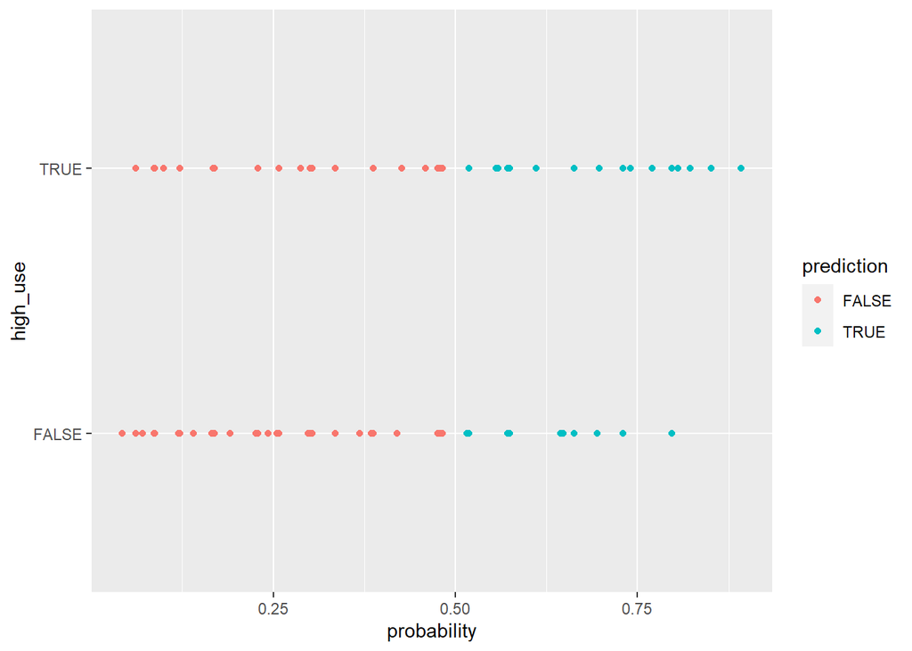

```r
ggplot(alc, aes(x = probability, y = high_use, col = prediction))+
  geom_point()
```

#### taking a look at the data visually.

```r
loss_func <- function(class, prob) {
  n_wrong <- abs(class - prob) > 0.5
  mean(n_wrong)
}
loss_func(class = alc$high_use, prob = alc$probability)
```

```
## [1] 0.2594595
```

##### Here I see that the average number of wrong predictions in my model is ~26%

```r
library(boot)

#setting up the training data from my model
cv_train <- cv.glm(data = alc, cost = loss_func, glmfit = m, K = nrow(alc))

#subselecting a pool of test data
cv_test <- cv.glm(data = alc, cost = loss_func, glmfit = m, K = 10)


cv_train$delta[1]
```

```
## [1] 0.2594595
```

```r
cv_test$delta[1]
```

```
## [1] 0.2675676
```